# Lecture 13: One Sample Hypothesis Tests

## STAT 324

### Ralph Trane

### University of Wisconsin–Madison<br><br>

### Spring 2020

* Secondhand smoke is of great health concern, especially for children.
* A sample was taken of 15 children in foster care suspected of being exposed to secondhand smoke, and the amount of cotinine (a metabolite of nicotine) in the urine was measured in ng/mL.
* Cotinine in unexposed children should be below 75 units. The data were as follows:

```r
library(tidyverse); theme_set(theme_bw())
secondhand_smoking <- tibble(cotinine = c( 29,  30,  53,  75,  34,
                                           21,  12,  58, 117, 119,
                                          115, 134, 253, 289, 287))
```

Based on this data, does it seem like the mean of cotinine of children exposed to secondhand smoke is greater than 75 ng/mL?

We would like to test `\(H_0: \mu = 75\)` vs. `\(H_A: \mu > 75\)`.

What significance level would you pick?

Recall, `\(\alpha = P(\text{type I error}) = P(\text{reject } H_0\ |\ H_0 \text{true})\)`. Also, decreasing `\(P(\text{type I error})\)` increases `\(P(\text{type II error})\)` (will see why later). So, picking `\(\alpha\)` can be done by assessing which is worse: type I or type II error.

Here, I would say type II error is worse: if we fail to reject the null, but we should have, we conclude that the children are fine, when in reality the levels of cotinine is too high.

So, let's pick `\(\alpha = 0.1\)`, which is traditionally relatively "large".

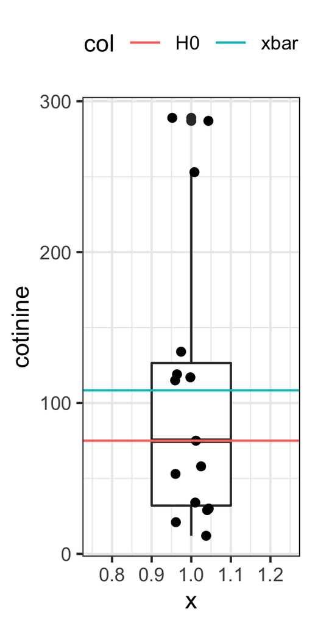

```r
hlines <- tibble(
  y = c(mean(secondhand_smoking$cotinine),
        75),
  col = c('xbar', 'H0')
)

ggplot(secondhand_smoking,
       aes(x = 1, y = cotinine)) +
  geom_boxplot(width = 0.2) +
  geom_jitter(height = 0,
              width = 0.05) +
  geom_hline(data = hlines,
             aes(yintercept = y,
                 color = col)) +
  xlim(c(0.75, 1.25)) +
  theme_bw() +
  theme(legend.position = "top")
```

Since the mean is our parameter of interest, we would like to use `\(T = \frac{\bar{X} - 75}{\widehat{\text{SD}}(\bar{X})}\)` as our metric for being "far from the null".

Here, since `\(H_A: \mu > 75\)`, we would reject `\(H_0\)` if `\(T\)` is much larger than `\(0\)`.

First, we calculate `\(T_{\text{obs}} = \frac{\bar{x}_{\text{obs}} - 75}{\widehat{\text{SD}}(\bar{X})}\)`. Per usual, we will use `\(\widehat{\text{SD}}(\bar{X}) = \hat{\sigma}/\sqrt{n} = S/\sqrt{n}\)`.

```r
sum_stats <- secondhand_smoking %>%
  summarize(xbar = mean(cotinine),
            SD = sd(cotinine),
            n = n(),
            T_obs = (xbar - 75)/(SD/sqrt(n)))
sum_stats
```

```
## # A tibble: 1 x 4
##    xbar    SD     n T_obs
##   <dbl> <dbl> <int> <dbl>
## 1  108.  95.6    15  1.35
```

Now the question is: is 1.3531105 much larger than 0?

To assess if 1.3531105 is "much larger than 0", we want to calculate `\(P(T > 1.3531105\ |\ H_0 \text{ true})\)`.

If `\(\bar{X} \sim N\)`, then `\(T \sim t_{n-1}\)`. So, need to check if `\(\bar{X} \sim N\)`.

Small `\(n\)`, so CLT might be a stretch. Let's consider the data:

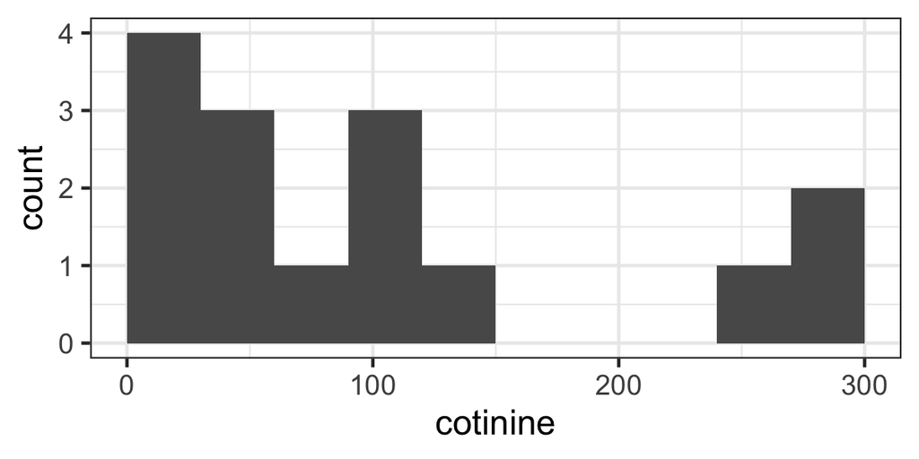

```r
ggplot(data = secondhand_smoking,
       aes(x = cotinine)) +
  geom_histogram(binwidth = 30, boundary = 0)
```

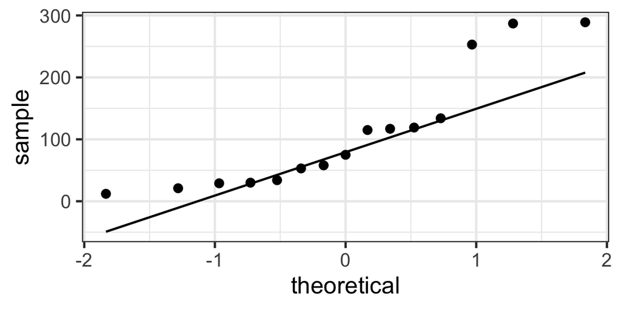

```r
ggplot(data = secondhand_smoking,
       aes(sample = cotinine)) +
  geom_qq() + geom_qq_line()
```

So it does NOT seem like `\(\bar{X} \sim N\)`. What else can we do to find the distribution of `\(T = \frac{\bar{X} - 75}{\widehat{\text{SD}}(\bar{X})}\)`?

Bootstrap!

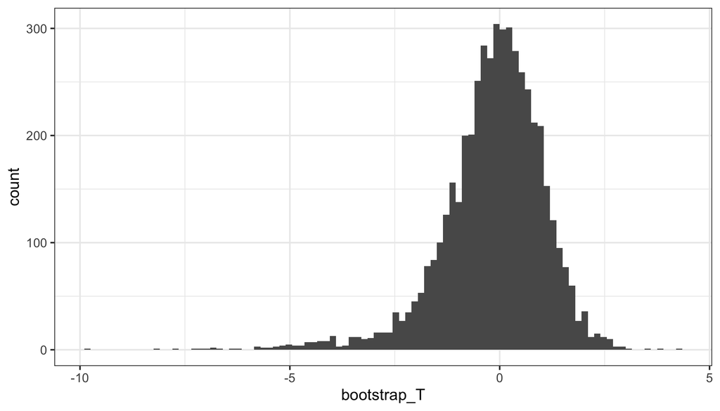

```r
xbar_orig <- sum_stats$xbar

bootstrap_samples <- tibble(i = 1:5000) %>%
  mutate(bootstrap_sample = map(i,
                                ~sample_n(secondhand_smoking,
                                          size = 15,
                                          replace = TRUE)$cotinine),
         bootstrap_mean = map_dbl(bootstrap_sample, mean),
         bootstrap_sd = map_dbl(bootstrap_sample, sd),
         bootstrap_T = (bootstrap_mean - xbar_orig)/
           (bootstrap_sd/sqrt(15)))

ggplot(bootstrap_samples,
       aes(x = bootstrap_T)) +
  geom_histogram(binwidth = 0.15, boundary = 0)
```

Now that we know the distribution of `\(T\)`, we can find `\(P(T > 1.3531105)\)`. But how?

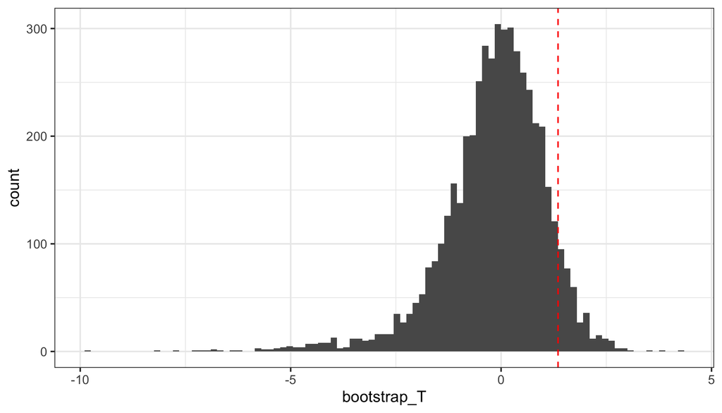

Now that we know the distribution of `\(T\)`, we can find `\(P(T > 1.3531105)\)`. But how? Proportion of the area under the curve to the right of 1.3531105.

The proportion of the area under the curve to the right of 1.3531105 is the same as the proportion of bootstrap `\(T\)`'s that are greater than 1.3531105. So `\(\text{p-value} = P(T > 1.3531105) = \frac{\# T_\text{boots} > 1.3531105}{5000}\)`.

```
n_larger <- sum(bootstrap_samples$bootstrap_T > 1.3531105)
n_larger
```

```
## [1] 354
```

```
p_value <- n_larger/5000
p_value
```

```
## [1] 0.0708
```

Since the p-value is smaller than our significance level `\(\alpha = 0.1\)`, we reject the null hypothesis: these data suggest that the true mean amount of cotinine in the urine is greater than 75 ng/mL.

**One Sample T-test**

If `\(\bar{X} \sim N\)`, the hypothesis `\(H_0: \mu = \mu_0\)` can be tested using the *test-statistic* `\(T = \frac{\bar{X} - \mu_0}{\widehat{\text{SD}}(\bar{X})}\)`.

Under the null hypothesis, `\(T \sim t_{n-1}\)`, and we reject `\(H_0\)` if the `\(\text{p-value} = P(T \text{ more extreme than } T_{\text{obs}}\ | H_0) < \alpha\)`.

* Here, `\(\widehat{\text{SD}}(\bar{X}) = s/\sqrt{n}\)`

**One Sample Test for Proportion**

If `\(P \sim N\)` (approximately), the hypothesis `\(H_0: \pi = \pi_0\)` can be tested using the *test-statistic* `\(Z = \frac{P - \pi_0}{\text{SD}_0(P)}\)`.

Under the null hypothesis, `\(Z \sim N(0,1)\)`, and we reject `\(H_0\)` if the `\(\text{p-value} = P(Z \text{ more extreme than } Z_{\text{obs}}\ | H_0) < \alpha\)`.

* Here, `\(\text{SD}_0(P) = \sqrt{\pi_0(1-\pi_0)/n}\)` is the standard deviation of `\(P\)` **IF** the null hypothesis is true.

**One Sample Bootstrap Test**

If `\(\bar{X}\)` is NOT normally distributed, but the observations are independent, we can test `\(H_0: \mu = \mu_0\)` using the *test-statistic* `\(T = \frac{\bar{X} - \mu_0}{\widehat{\text{SD}}(\bar{X})}\)`.

We estimate the distribution of `\(T\)` under the null by the distribution of `\(T_{\text{boot}}\)`, and reject `\(H_0\)` if the p-value = `\(P(T_\text{boot} \text{ more extreme than } T_\text{obs}) < \alpha\)`.

Here,

* `\(B =\)` number of bootstrap samples created.
* `\(T_{\text{boot}} = \frac{\bar{x}_\text{boot} - \bar{x}_\text{obs}}{s_{\text{boot}}/\sqrt{n}}\)` is calculated for each of the bootstrap samples.

**"More extreme"**

What it means to be more extreme is determined by the alternative hypothesis:

* if `\(H_A: \mu > \mu_0\)`, then "more extreme" = "greater than", and p-value = `\(P(T > T_{\text{obs}})\)`

* if `\(H_A: \mu < \mu_0\)`, then "more extreme" = "smaller than", and p-value = `\(P(T < T_{\text{obs}})\)`

* if `\(H_A: \mu \ne \mu_0\)`, then "more extreme" = "further from 0", and p-value = `\(P(T < -|T_{\text{obs}}|) + P(T > |T_{\text{obs}}|)\)`

For test of proportion, replace `\(\mu\)` with `\(\pi\)`, and `\(T\)` with `\(Z\)`.

Recall: for every hypothesis test, there is a conclusion. For every conclusion, one of three things will happen:

* we make the right decision
    - i.e. reject when `\(H_0\)` is false, do not reject when `\(H_0\)` is true

* we make a type I error
    - i.e. reject when `\(H_0\)` is actually true

* we make a type II error
    - i.e. fail to reject when `\(H_0\)` is actually false

We have full control over the type I error rate - it is exactly `\(\alpha\)`. To see this, say we are testing `\(H_0: \mu = \mu_0\)` against `\(H_A: \mu \neq \mu_0\)`.

`$$\begin{aligned}
  P(\text{reject } H_0\ |\ H_0 \text{ true}) &= P(T \text{ very far from 0}\ |\ H_0 \text{ true}) \\
                                             &= P(T > t_{n-1, \alpha/2}\ |\ H_0 \text{ true}) + P(T < -t_{n-1, \alpha/2}\ |\ H_0 \text{ true})\\
                                             &= \alpha
\end{aligned}$$`

Similarly can be done for the two other alternative hypotheses.

To get a better sense of how this works, we will consider a simple case that we haven't talked about yet: one sample hypothesis test with known variance `\(\sigma^2\)`.

Remember: good old paint thickness data.

```r
paint_thickness <- tibble(
  thickness = c(1.29, 1.12, 0.88, 1.65, 1.48, 1.59, 1.04, 0.83,
                1.76, 1.31, 0.88, 1.71, 1.83, 1.09, 1.62, 1.49)
)
```

Let us assume that `\(\bar{X} \sim N\)`, and that we know the true variance `\(\sigma^2 = 0.115\)`.

When testing `\(H_0: \mu = 1.5\)` against `\(H_A: \mu \neq 1.5\)` using `\(\alpha = 0.05\)`, we would reject when `\(\bar{x}_\text{obs}\)` is very, very far from `\(1.5\)`.

Actually, we reject when `\(\bar{x}_\text{obs}\)` is so far from `\(1.5\)` that the probability of `\(\bar{X}\)` being even further from `\(1.5\)` is less than `\(0.05\)`: `\(2\cdot P(\bar{X} > |\bar{x}_\text{obs}|\ |\ H_0 \text{ true}) < 0.05\)`.

When `\(H_0\)` is true, `\(\bar{X} \sim N(1.5, 0.115/16)\)`. So, when `\(H_0\)` is true, `\(\bar{X}\)` follows this distribution:

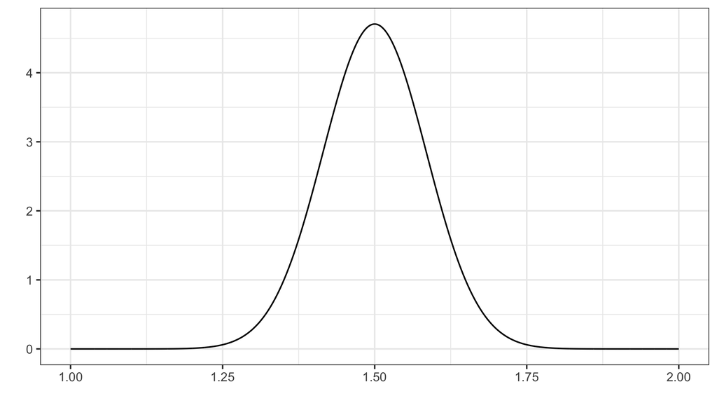

Will reject when `\(\bar{X}\)` outside red dotted lines.

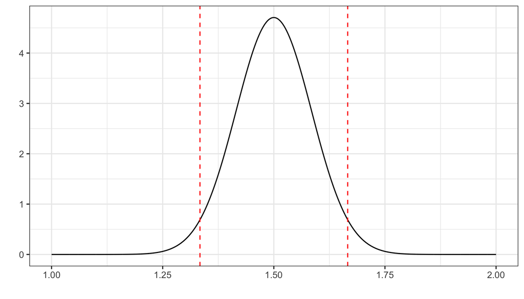

But to talk about type II error rate (or power), we need to find `\(P(\text{fail to reject } H_0\ |\ H_0 \text{ not true}) = P(\text{fail to reject } H_0\ |\ H_A \text{ true})\)` (or `\(P(\text{reject } H_0\ |\ H_0 \text{ not true})\)`).

Assuming we know the true `\(\sigma^2 = 0.115\)`, and that the null hypothesis is true, then `\(\bar{X} \sim N(1.5, 0.115/16)\)`.

So, we reject when `\(\bar{X}\)` outside red dotted lines. I.e. if `\(0.025 > P\left(\bar{X} > |\bar{x}_\text{obs}|\right)\)`.

```r
X_H0 <- Normal(mu = 1.5, sigma = sqrt(0.115/16))

quantile(X_H0, c(0.025, 0.975))
```

```
## [1] 1.333836 1.666164
```

So, we reject when `\(\bar{x} < 1.33\)` or `\(\bar{x} > 1.66\)`.

But what if the true mean is NOT `\(1.5\)`? What if, instead, it is `\(1.3\)`? What is `\(P(\text{type II error})\)`?

To find the probability of rejecting, we need to look at a different curve, because if `\(\mu = 1.3\)`, then `\(\bar{X} \sim N(1.3, 0.115/16)\)`.

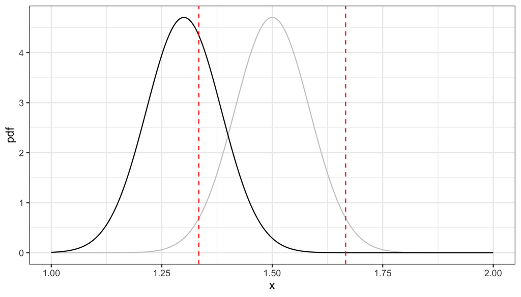

But what if the true mean is NOT `\(1.5\)`? What if, instead, it is `\(1.3\)`? What is `\(P(\text{type II error})\)`?

To find the probability of rejecting, we need to look at a different curve, because if `\(\mu = 1.3\)`, then `\(\bar{X} \sim N(1.3, 0.115/16)\)`.

$$
`\begin{aligned}
  P(\text{type II error}) &= P(\text{fail to reject } |\ \mu = 1.3) \\
                          &= P(1.33 < \bar{X} < 1.66\ |\ \mu = 1.3) \\
                          &= P(\bar{X} < 1.66\ |\ \mu = 1.3) - P(\bar{X} < 1.33\ |\ \mu = 1.3)
\end{aligned}`
$$

```r
X_HA <- Normal(1.3, sqrt(0.115/16))

cdf(X_HA, 1.66) - cdf(X_HA, 1.33)
```

```
## [1] 0.3617108
```

What can we do to do better?

Increase sample size!

What sample size do we need to be able to distinguish between `\(\mu = 1.5\)` and `\(\mu = 1.3\)` most of the time? Say, `\(80\%\)` of the time?

That is, what should `\(n\)` be such that `\(P(\text{reject } H_0: \mu = 1.5\ |\ \mu = 1.3) = 0.8\)`?

More general, if we are testing `\(H_0: \mu = \mu_0\)` against `\(H_A: \mu \neq \mu_0\)` at significance level `\(\alpha\)`, what sample size is needed to make sure that `\(P(\text{reject } H_0\ |\ \mu = \mu_A) = 1 - \beta\)`?

Turns out, this is approximately

`\begin{equation}
  n \approx \left(\frac{\sigma(z_{\alpha/2} + z_\beta)}{\mu_0 - \mu_A}\right)^2
\end{equation}`

In our specific example, `\(\sigma = 0.34\)`, `\(\alpha = 0.05\)`, `\(\beta = 0.2\)`, `\(\mu_0 = 1.5\)`, and `\(\mu_A = 1.3\)`.

We can find `\(z_{0.025}\)` and `\(z_{\beta}\)`:

```r
Z <- Normal()
quantile(Z, c(1-0.025, 1-0.2))
```

```
## [1] 1.9599640 0.8416212
```

So, `\(n \approx \left(\frac{0.34(1.96 + 0.84)}{1.5 - 1.3} \right)^2 = 22.6576\)`.

To have `\(80\%\)` power to reject `\(1.5\)` as the true mean if the true mean is in fact `\(1.3\)`, we would need 23 samples.

Note:

* sample size depends only on standard deviation, `\(\alpha\)`, `\(\beta\)`, and *difference* between true and hypothesized means.

* in practice, it goes as follows:

- researchers pick desired `\(\alpha\)` and `\(\beta\)`

- from previous, well-done experiments, a solid estimate of `\(\sigma\)` is optained

- from expert knowledge, a "minimal interesting difference" is chosen (i.e. `\(\mu_0 - \mu_A\)`)

- based on this, needed sample size is determined.